# 高鐵問卷結果統計

# 載入結果表單

```r
data_pq <- read_csv("I:\\思瑋老師文件備份\\Sihwei Project\\PQ Questionnaires\\高鐵問卷_psytoolkit\\data_for_r_stats.csv")

# Relevel" 將 evid, epis讓 NEU coding 為 0
data_pq <- data_pq %>%
  mutate(evid=as.factor(evid), epis=as.factor(epis), q_type=as.factor(q_type))

data_pq <- data_pq %>% mutate(evid=relevel(evid, ref="NEU"), epis=relevel(epis, ref="NEU"))
```

# 問句種類:

```r
levels(data_pq$q_type)
```

```
## [1] "HiNeg-NotP" "HiNeg-P"    "NotP-ba"    "NotP-ma"    "P-ba"
## [6] "P-ma"       "SBS-NotP"   "SBS-P"
```

```r
levels(data_pq$epis)
```

```
## [1] "NEU" "NEG" "POS"
```

```r
levels(data_pq$evid)
```

```
## [1] "NEU" "NEG" "POS"
```

```r
summary(data_pq$q_type)
```

```
## HiNeg-NotP    HiNeg-P    NotP-ba    NotP-ma       P-ba       P-ma   SBS-NotP
##        270        270        270        270        270        270        270
##      SBS-P
##        270
```

```r
summary(data_pq$epis)
```

```
## NEU NEG POS
## 720 720 720
```

```r
summary(data_pq$evid)
```

```
## NEU NEG POS
## 720 720 720
```

# 針對各種問句形式做Logistic Regression

對各種問句分開來看`glm(, family="binominal”)` ，用來看Evid, Epis 等變數如何影響問句的使用 (每個變數皆會給出coef, p value)。

## 需要的資料格式

以`P-ma`問句為例:

```r
Q_P_ma <- data_pq %>%
  filter(q_type=="P-ma")
Q_P_ma
```

| subject | sex | age | epis | evid | q_type | acceptabl_raw | acceptable |
| --- | --- | --- | --- | --- | --- | --- | --- |
| 1 | 1 | 2 | NEU | NEG | P-ma | 2 | FALSE |
| 2 | 1 | 3 | NEU | NEG | P-ma | 2 | FALSE |
| 3 | 2 | 2 | NEU | NEG | P-ma | 2 | FALSE |
| 4 | 1 | 2 | NEU | NEG | P-ma | 2 | FALSE |
| 5 | 1 | 2 | NEU | NEG | P-ma | 2 | FALSE |
| 6 | 1 | 4 | NEU | NEG | P-ma | 1 | TRUE |
| 7 | 2 | 3 | NEU | NEG | P-ma | 1 | TRUE |
| 8 | 1 | 3 | NEU | NEG | P-ma | 2 | FALSE |
| 9 | 2 | 3 | NEU | NEG | P-ma | 1 | TRUE |
| 10 | 2 | 3 | NEU | NEG | P-ma | 2 | FALSE |

[output cut: 260 more lines]

```r
str(Q_P_ma)
```

```
## spec_tbl_df [270 x 8] (S3: spec_tbl_df/tbl_df/tbl/data.frame)
##  $ subject      : num [1:270] 1 2 3 4 5 6 7 8 9 10 ...
##  $ sex          : num [1:270] 1 1 2 1 1 1 2 1 2 2 ...
##  $ age          : num [1:270] 2 3 2 2 2 4 3 3 3 3 ...
##  $ epis         : Factor w/ 3 levels "NEU","NEG","POS": 1 1 1 1 1 1 1 1 1 1 ...
##  $ evid         : Factor w/ 3 levels "NEU","NEG","POS": 2 2 2 2 2 2 2 2 2 2 ...
##  $ q_type       : Factor w/ 8 levels "HiNeg-NotP","HiNeg-P",..: 6 6 6 6 6 6 6 6 6 6 ...
##  $ acceptabl_raw: num [1:270] 2 2 2 2 2 1 1 2 1 2 ...
##  $ acceptable   : logi [1:270] FALSE FALSE FALSE FALSE FALSE TRUE ...
##  - attr(*, "spec")=
##   .. cols(
##   ..   subject = col_double(),
##   ..   sex = col_double(),
##   ..   age = col_double(),
##   ..   epis = col_character(),
##   ..   evid = col_character(),
##   ..   q_type = col_character(),
##   ..   acceptabl_raw = col_double(),
##   ..   acceptable = col_logical()
##   .. )
##  - attr(*, "problems")=<externalptr>
```

## 「P嗎」(P-ma)結果

```r
fmt_P_ma <- data_pq %>%
  filter(q_type=="P-ma") %>%
  glm(formula = acceptable ~ epis + evid, family=binomial())
summary(fmt_P_ma)
```

```
##
## Call:
## glm(formula = acceptable ~ epis + evid, family = binomial(),
##     data = .)
##
## Deviance Residuals:
##     Min       1Q   Median       3Q      Max
## -2.1056  -0.8440  -0.3781   0.7325   2.2829
##
## Coefficients:
##             Estimate Std. Error z value Pr(>|z|)
## (Intercept)  1.17858    0.33891   3.478 0.000506 ***
## episNEG      0.07316    0.38256   0.191 0.848339
## episPOS      0.92283    0.38529   2.395 0.016614 *
## evidNEG     -2.02754    0.35509  -5.710 1.13e-08 ***
## evidPOS     -3.78087    0.45692  -8.275  < 2e-16 ***
## ---
## Signif. codes:  0 '***' 0.001 '**' 0.01 '*' 0.05 '.' 0.1 ' ' 1
##
## (Dispersion parameter for binomial family taken to be 1)
##
##     Null deviance: 368.93  on 269  degrees of freedom
## Residual deviance: 257.73  on 265  degrees of freedom
## AIC: 267.73
##
## Number of Fisher Scoring iterations: 4
```

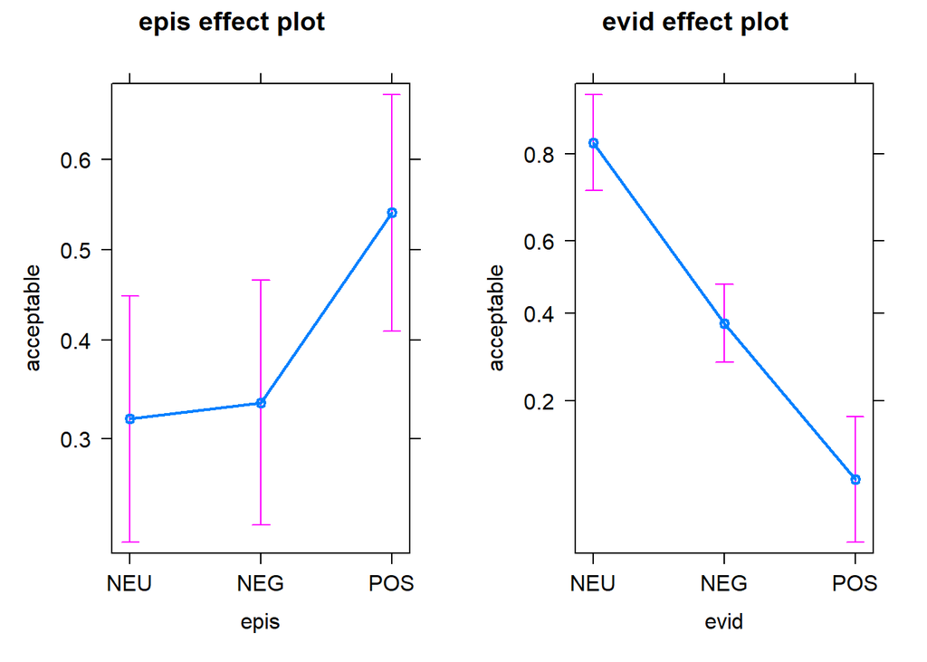

```r
# 請參考 https://data.library.virginia.edu/visualizing-the-effects-of-logistic-regression/ 看數值如何讀出的
# a <- allEffects(fmt_P_ma)
# a$epis$model.matrix
# invLogit <- function(x) exp(x)/(1 + exp(x))
# invLogit(a$epis$model.matrix %*% coef(fmt_P_ma))
plot(allEffects(fmt_P_ma))
```

```r
# plot_model(fmt_P_ma, show.values = TRUE, value.offset = .3)
```

### 解讀

- evid 較顯著: NEG/POS 會顯著降低P-ma的出現，而NEU則是會增加P-ma的出現。
- epis: Pos顯著，相較之下不如evid那麼顯著。

## 「P吧」(P-ba)結果

```r
fmt_P_ba <- data_pq %>%
  filter(q_type=="P-ba") %>%
  glm(formula = acceptable ~ epis + evid, family=binomial())
summary(fmt_P_ba)
```

```
##
## Call:
## glm(formula = acceptable ~ epis + evid, family = binomial(),
##     data = .)
##
## Deviance Residuals:
##     Min       1Q   Median       3Q      Max
## -1.8196  -0.8006  -0.5368   0.9213   2.1666
##
## Coefficients:
##             Estimate Std. Error z value Pr(>|z|)
## (Intercept)   0.6373     0.3017   2.112   0.0347 *
## episNEG      -0.8912     0.3652  -2.440   0.0147 *
## episPOS       0.8062     0.3333   2.419   0.0156 *
## evidNEG      -1.6107     0.3424  -4.705 2.54e-06 ***
## evidPOS      -1.9927     0.3594  -5.545 2.94e-08 ***
## ---
## Signif. codes:  0 '***' 0.001 '**' 0.01 '*' 0.05 '.' 0.1 ' ' 1
##
## (Dispersion parameter for binomial family taken to be 1)
##
##     Null deviance: 358.98  on 269  degrees of freedom
## Residual deviance: 298.10  on 265  degrees of freedom
## AIC: 308.1
##
## Number of Fisher Scoring iterations: 4
```

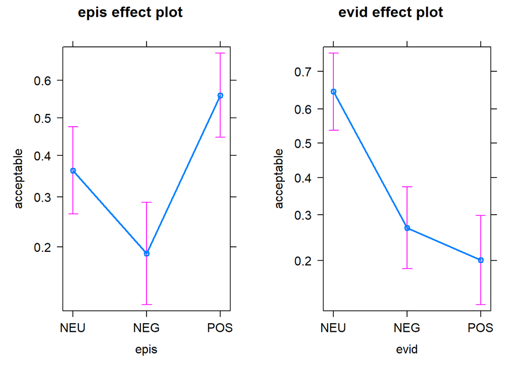

```r
plot(allEffects(fmt_P_ba))
```

```r
# plot_model(fmt_P_ba, show.values = TRUE, value.offset = .3)
```

### 解讀

- evid 較顯著: NEG/POS 會顯著降低P-ba的出現 -> 如果售票員已經提供資訊了，買票的人就不會再做出推測。
- epis:
  - POS 時，P-ba的出現上升。 -> 說話者根據前有的知識，帶著確信的心態去問:「所以是有很早的車吧」
  - NEG 時，P-ba的出現下降。 -> 說話者根據前有的知識，帶著確信的心態去問:「所以是有很早的車吧」

## 「沒有…P嗎」(NotP-ma)結果

```r
fmt_NotP_ma <- data_pq %>%
  filter(q_type=="NotP-ma") %>%
  glm(formula = acceptable ~ epis + evid, family=binomial())
summary(fmt_NotP_ma)
```

```
##
## Call:
## glm(formula = acceptable ~ epis + evid, family = binomial(),
##     data = .)
##
## Deviance Residuals:
##     Min       1Q   Median       3Q      Max
## -1.6999  -0.8609  -0.4524   0.9024   2.2112
##
## Coefficients:
##             Estimate Std. Error z value Pr(>|z|)
## (Intercept)  -2.3539     0.4055  -5.805 6.43e-09 ***
## episNEG       0.1260     0.3551   0.355 0.722752
## episPOS       0.6138     0.3537   1.735 0.082693 .
## evidNEG       2.9160     0.4099   7.114 1.13e-12 ***
## evidPOS       1.5521     0.4031   3.851 0.000118 ***
## ---
## Signif. codes:  0 '***' 0.001 '**' 0.01 '*' 0.05 '.' 0.1 ' ' 1
##
## (Dispersion parameter for binomial family taken to be 1)
##
##     Null deviance: 360.85  on 269  degrees of freedom
## Residual deviance: 289.25  on 265  degrees of freedom
## AIC: 299.25
##
## Number of Fisher Scoring iterations: 4
```

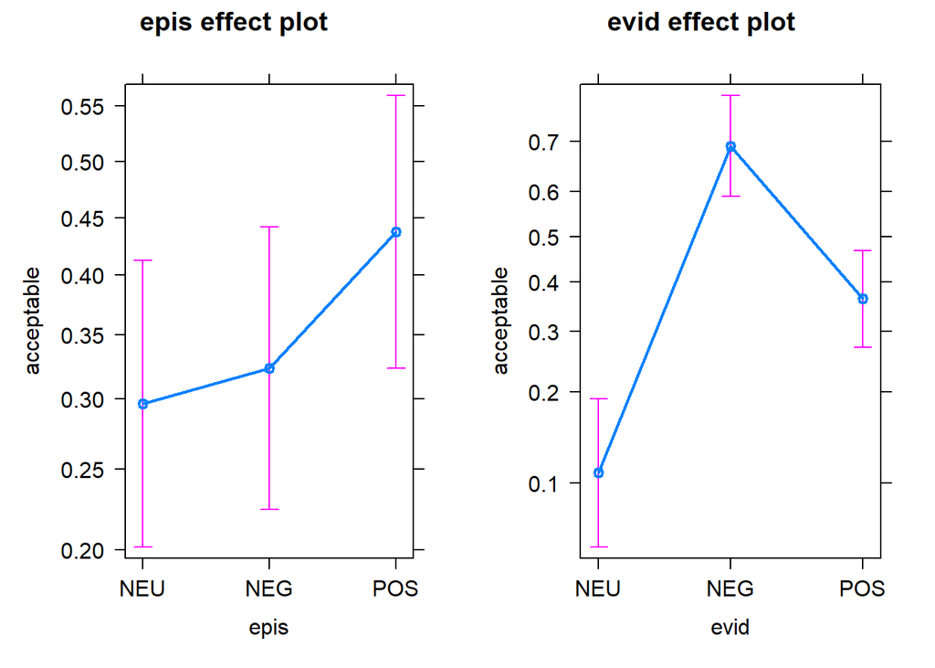

```r
plot(allEffects(fmt_NotP_ma))
```

```r
# plot_model(fmt_NotP_ma, show.values = TRUE, value.offset = .3)
```

### 解讀

- evid:
  - NEG 會顯著增加NotP-ma的出現 -> 售票員已經說沒有車，但還是會問「沒有很早的車嗎」來確認。
  - POS 會顯著增加NotP-ma的出現 -> 售票員已經說有車，但還是會問「沒有很早的車嗎」來看有沒有更早的。
  - NEU 會減少NotP-ma的出現 -> 售票員是單純疑問（你要買幾點的車？）的話，可能就會直接說要幾點的，不會用反問的方式。
- epis:
  - 看起來沒顯著

## 「沒有…P吧」(NotP-ba)

```r
fmt_NotP_ba <- data_pq %>%
  filter(q_type=="NotP-ba") %>%
  glm(formula = acceptable ~ epis + evid, family=binomial())
summary(fmt_NotP_ba)
```

```
##
## Call:
## glm(formula = acceptable ~ epis + evid, family = binomial(),
##     data = .)
##
## Deviance Residuals:
##     Min       1Q   Median       3Q      Max
## -0.8794  -0.4741  -0.4370  -0.3790   2.3106
##
## Coefficients:
##               Estimate Std. Error z value Pr(>|z|)
## (Intercept) -2.129e+00  4.314e-01  -4.935 8.01e-07 ***
## episNEG      1.379e+00  4.399e-01   3.134  0.00173 **
## episPOS     -2.656e-15  5.246e-01   0.000  1.00000
## evidNEG     -1.716e-01  4.148e-01  -0.414  0.67905
## evidPOS     -4.687e-01  4.373e-01  -1.072  0.28386
## ---
## Signif. codes:  0 '***' 0.001 '**' 0.01 '*' 0.05 '.' 0.1 ' ' 1
##
## (Dispersion parameter for binomial family taken to be 1)
##
##     Null deviance: 229.99  on 269  degrees of freedom
## Residual deviance: 213.16  on 265  degrees of freedom
## AIC: 223.16
##
## Number of Fisher Scoring iterations: 5
```

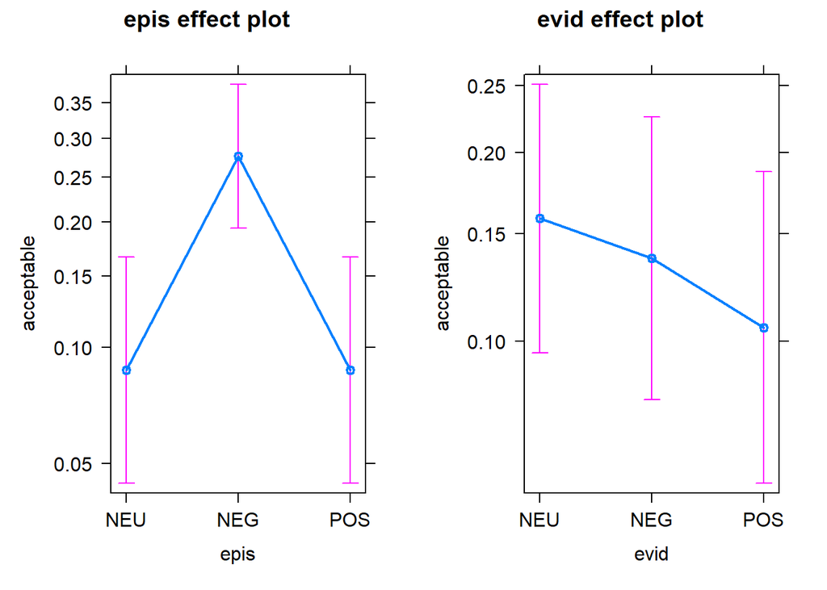

```r
plot(allEffects(fmt_NotP_ba))
```

```r
# plot_model(fmt_NotP_ma, show.values = TRUE, value.offset = .3)
```

## 「不是有…P嗎」(HiNeg-P)結果

```r
fmt_HiNeg_P <- data_pq %>%
  filter(q_type=="HiNeg-P") %>%
  glm(formula = acceptable ~ epis + evid, family=binomial())
summary(fmt_HiNeg_P)
```

```
##
## Call:
## glm(formula = acceptable ~ epis + evid, family = binomial(),
##     data = .)
##
## Deviance Residuals:
##     Min       1Q   Median       3Q      Max
## -1.6754  -1.0360  -0.3113   1.0041   2.6663
##
## Coefficients:
##             Estimate Std. Error z value Pr(>|z|)
## (Intercept)  -3.5255     0.5348  -6.592 4.33e-11 ***
## episNEG       0.5225     0.3637   1.437 0.150845
## episPOS       1.2215     0.3710   3.292 0.000994 ***
## evidNEG       3.4255     0.5208   6.577 4.80e-11 ***
## evidPOS       2.6610     0.5158   5.159 2.49e-07 ***
## ---
## Signif. codes:  0 '***' 0.001 '**' 0.01 '*' 0.05 '.' 0.1 ' ' 1
##
## (Dispersion parameter for binomial family taken to be 1)
##
##     Null deviance: 354.87  on 269  degrees of freedom
## Residual deviance: 270.57  on 265  degrees of freedom
## AIC: 280.57
##
## Number of Fisher Scoring iterations: 5
```

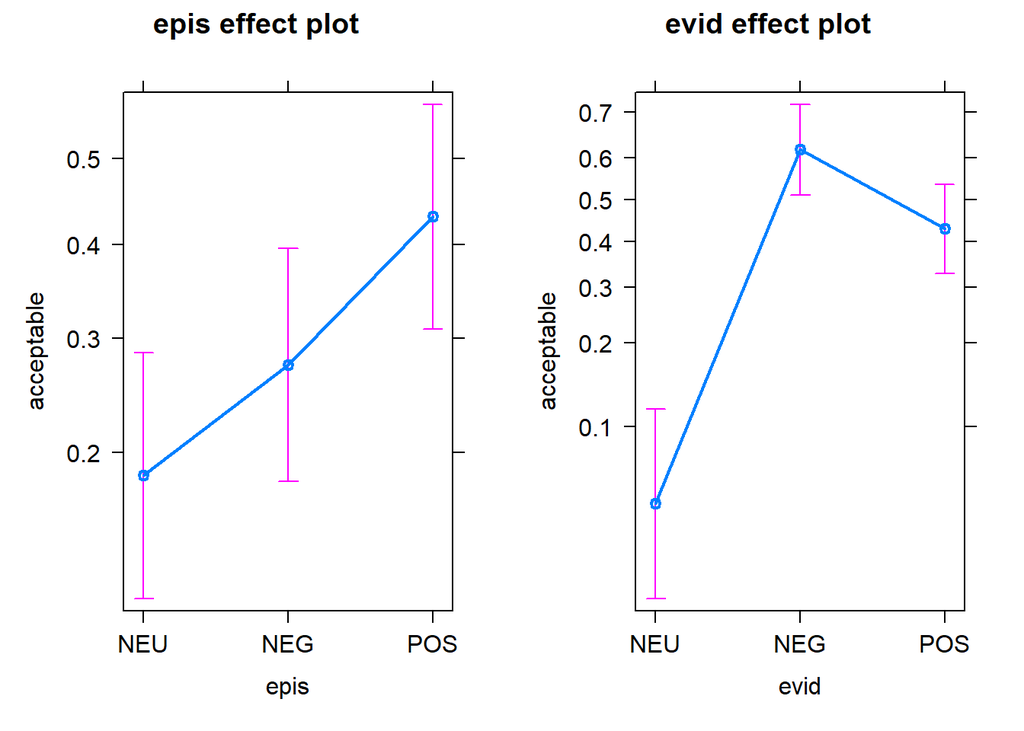

```r
plot(allEffects(fmt_HiNeg_P))
```

```r
# plot_model(fmt_HiNeg_P, show.values = TRUE, value.offset = .3)
```

### 解讀

- evid:
  - POS, NEG 會增加 HiNeg-P 出現的機率:
  - NEU 會減少 HiNeg-P 出現的機率: 因為售票員問「你要幾點的車」，一般來說不會用HiNeg來回覆
- epis: POS增加 HiNeg-P 的出現 -> 合理，可以確認哥哥所言是否為真

## 「不是沒有…P嗎」(HiNeg-NotP)結果

```r
fmt_HiNeg_NotP <- data_pq %>%
  filter(q_type=="HiNeg-NotP") %>%
  glm(formula = acceptable ~ epis + evid, family=binomial())
summary(fmt_HiNeg_NotP)
```

```
##
## Call:
## glm(formula = acceptable ~ epis + evid, family = binomial(),
##     data = .)
##
## Deviance Residuals:
##     Min       1Q   Median       3Q      Max
## -1.2287  -0.3969  -0.1631  -0.0991   3.2616
##
## Coefficients:
##             Estimate Std. Error z value Pr(>|z|)
## (Intercept)  -4.3129     0.7705  -5.597 2.18e-08 ***
## episNEG       1.8958     0.5733   3.307 0.000944 ***
## episPOS      -1.0012     0.8697  -1.151 0.249698
## evidNEG      -0.4300     0.9392  -0.458 0.647095
## evidPOS       2.5370     0.6702   3.785 0.000154 ***
## ---
## Signif. codes:  0 '***' 0.001 '**' 0.01 '*' 0.05 '.' 0.1 ' ' 1
##
## (Dispersion parameter for binomial family taken to be 1)
##
##     Null deviance: 175.54  on 269  degrees of freedom
## Residual deviance: 119.78  on 265  degrees of freedom
## AIC: 129.78
##
## Number of Fisher Scoring iterations: 6
```

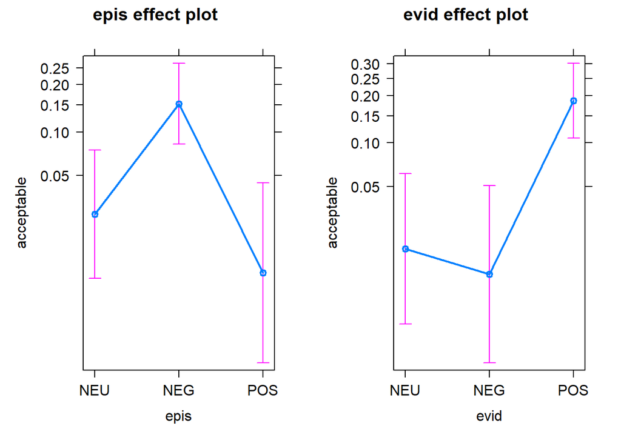

```r
plot(allEffects(fmt_HiNeg_NotP))
```

```r
# plot_model(fmt_HiNeg_NotP, show.values = TRUE, value.offset = .3)
```

### 解讀

- epis=NEG, evid=POS時，此問句最合適

## 「是不是有…P」(SBS-P)結果

```r
fmt_SBS_P <- data_pq %>%
  filter(q_type=="SBS-P") %>%
  glm(formula = acceptable ~ epis + evid, family=binomial())
summary(fmt_SBS_P)
```

```
##
## Call:
## glm(formula = acceptable ~ epis + evid, family = binomial(),
##     data = .)
##
## Deviance Residuals:
##     Min       1Q   Median       3Q      Max
## -1.6732  -1.0354  -0.6525   1.0685   1.8175
##
## Coefficients:
##             Estimate Std. Error z value Pr(>|z|)
## (Intercept)   0.5811     0.2872   2.023  0.04302 *
## episNEG      -0.5597     0.3215  -1.741  0.08167 .
## episPOS       0.5355     0.3140   1.705  0.08818 .
## evidNEG      -0.8548     0.3132  -2.729  0.00635 **
## evidPOS      -1.4602     0.3266  -4.470  7.8e-06 ***
## ---
## Signif. codes:  0 '***' 0.001 '**' 0.01 '*' 0.05 '.' 0.1 ' ' 1
##
## (Dispersion parameter for binomial family taken to be 1)
##
##     Null deviance: 372.16  on 269  degrees of freedom
## Residual deviance: 339.52  on 265  degrees of freedom
## AIC: 349.52
##
## Number of Fisher Scoring iterations: 4
```

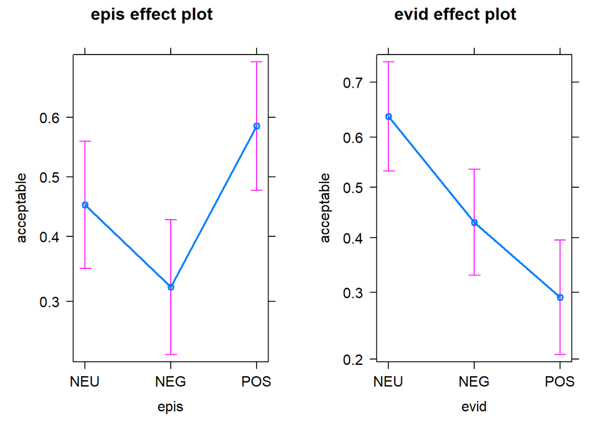

```r
plot(allEffects(fmt_SBS_P))
```

```r
# plot_model(fmt_SBS_P, show.values = TRUE, value.offset = .3)
```

### 解讀

- evid=NEG/POS時，比起EVID=NEU時，都會大幅減少“SBS-P”的出現

## 「是不是沒有…P」(SBS-NotP)結果

```r
fmt_SBS_NotP <- data_pq %>%
  filter(q_type=="SBS-NotP") %>%
  glm(formula = acceptable ~ epis + evid, family=binomial())
summary(fmt_SBS_NotP)
```

```
##
## Call:
## glm(formula = acceptable ~ epis + evid, family = binomial(),
##     data = .)
##
## Deviance Residuals:
##     Min       1Q   Median       3Q      Max
## -1.8232  -1.0494   0.6487   1.0164   1.5580
##
## Coefficients:
##             Estimate Std. Error z value Pr(>|z|)
## (Intercept)   0.3913     0.2833   1.381  0.16731
## episNEG      -0.2040     0.3197  -0.638  0.52343
## episPOS      -0.7001     0.3198  -2.189  0.02858 *
## evidNEG       1.0604     0.3272   3.241  0.00119 **
## evidPOS      -0.5523     0.3054  -1.808  0.07055 .
## ---
## Signif. codes:  0 '***' 0.001 '**' 0.01 '*' 0.05 '.' 0.1 ' ' 1
##
## (Dispersion parameter for binomial family taken to be 1)
##
##     Null deviance: 370.96  on 269  degrees of freedom
## Residual deviance: 339.81  on 265  degrees of freedom
## AIC: 349.81
##
## Number of Fisher Scoring iterations: 4
```

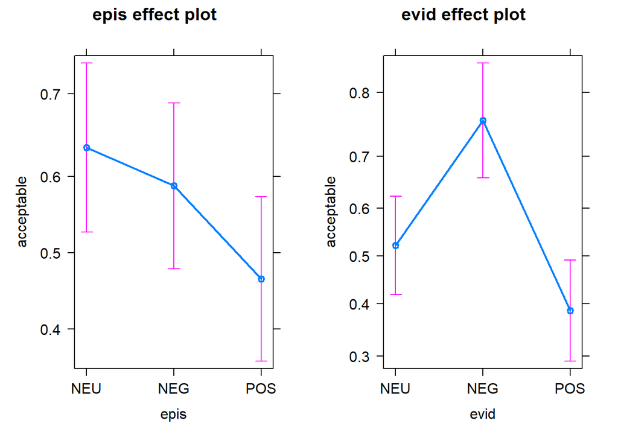

```r
plot(allEffects(fmt_SBS_NotP))
```

```r
# plot_model(fmt_SBS_NotP, show.values = TRUE, value.offset = .3)
```

### 解讀

- evid:
  - NEG 會增加 SBS-NotP 的出現: 雖然售票員說沒票，可是還是可以用這個問句再確認一次

# 2-1. 對9個情境中的8種問句的比較

- 先使用 2-by-k test，看單一情境當中，整體有無顯著差異
  - 九種情境各自都有顯著的不同

```r
chi_test <- function(p, v) {
  d <- data_pq %>%
    filter(epis==p, evid==v)

  d <-  xtabs(~q_type + acceptable, d)

  d <- d %>%
  as_tibble() %>%
  spread(q_type, n)

  chisq.test(d[, 2:9])
}
```

## EPIS = NEU / EVID = NEU 顯著不同

```r
chi_test("NEU", "NEU")
```

```
##
##  Pearson's Chi-squared test
##
## data:  d[, 2:9]
## X-squared = 104.42, df = 7, p-value < 2.2e-16
```

## EPIS = NEU / EVID = POS 顯著不同

```r
chi_test("NEU", "POS")
```

```
##
##  Pearson's Chi-squared test
##
## data:  d[, 2:9]
## X-squared = 40.248, df = 7, p-value = 1.128e-06
```

## EPIS = NEU / EVID = NEG 顯著不同

```r
chi_test("NEU", "NEG")
```

```
##
##  Pearson's Chi-squared test
##
## data:  d[, 2:9]
## X-squared = 73.493, df = 7, p-value = 2.9e-13
```

## EPIS = POS / EVID = NEU 顯著不同

```r
chi_test("POS", "NEU")
```

```
##
##  Pearson's Chi-squared test
##
## data:  d[, 2:9]
## X-squared = 121.99, df = 7, p-value < 2.2e-16
```

## EPIS = POS / EVID = POS 顯著不同

```r
chi_test("POS", "POS")
```

```
##
##  Pearson's Chi-squared test
##
## data:  d[, 2:9]
## X-squared = 38.223, df = 7, p-value = 2.748e-06
```

## EPIS = POS / EVID = NEG 顯著不同

```r
chi_test("POS", "NEG")
```

```
##
##  Pearson's Chi-squared test
##
## data:  d[, 2:9]
## X-squared = 83.334, df = 7, p-value = 2.874e-15
```

## EPIS = NEG / EVID = NEU 顯著不同

```r
chi_test("NEG", "NEU")
```

```
##
##  Pearson's Chi-squared test
##
## data:  d[, 2:9]
## X-squared = 85.934, df = 7, p-value = 8.441e-16
```

## EPIS = NEG / EVID = POS 顯著不同

```r
chi_test("NEG", "POS")
```

```
##
##  Pearson's Chi-squared test
##
## data:  d[, 2:9]
## X-squared = 17.554, df = 7, p-value = 0.01415
```

## EPIS = NEG / EVID = NEG 顯著不同

```r
chi_test("NEG", "NEG")
```

```
##
##  Pearson's Chi-squared test
##
## data:  d[, 2:9]
## X-squared = 83.34, df = 7, p-value = 2.865e-15
```

# 2-2. 比較同一情境中，兩個問句之間有無顯著不同

- 使用 sign-test

```r
sign.test <- function(p, v, q1, q2) {
  d <- data_pq %>%
  filter(epis==p, evid==v) %>%
  filter( q_type==q1 | q_type==q2) %>%
  dplyr::select(subject, q_type, acceptable)

d <- d %>%
  spread(q_type, acceptable)

d.diff <- d[[q1]] - d[[q2]]
#
# %>%
#    mutate(diff = d[[q1]] - d[[q2]])
#
# d$diff

SIGN.test(d.diff, alternative="two.sided", conf.level=0.95)

}
```

## 比較 NEU/NEU 中的 P-ma (86%) 和 P-ba (76%): 沒有 < 0.05，兩者間無顯著差別

```r
sign.test(p="NEU", v="NEU", q1="P-ma", q2="P-ba")
```

```
##
##  One-sample Sign-Test
##
## data:  d.diff
## s = 5, p-value = 0.4531
## alternative hypothesis: true median is not equal to 0
## 95 percent confidence interval:
##  0 0
## sample estimates:
## median of x
##           0
##
## Achieved and Interpolated Confidence Intervals:
##
##                   Conf.Level L.E.pt U.E.pt
## Lower Achieved CI     0.9013      0      0
## Interpolated CI       0.9500      0      0
## Upper Achieved CI     0.9572      0      0
```